# 01_15B_Population_Data_Analysis

### 주민등록 인구 통계(2023년 10월) - 추가 분석

### 학습 내용

- 하나의 `행정구역` 문자열에서 **행정구역 코드**를 꺼내 시도 / 시군구 / 읍면동 단계로 나누기
- 시도·시군구별 인구 순위, **수도권 집중**, **성비**, **세대당 인구**(1~2인 세대 경향) 비교하기
- plotly로 **인터랙티브 차트**(트리맵, 산점도) 만들기

### 내용

- 0. 기본 분석 돌아보기 - 무엇을 보완할까?
- 1. 데이터 준비 - 구조 확인과 행정구역 단계 나누기
- 2. 시도별 인구와 수도권 집중
- 3. 시군구 순위 - 인구가 많은 / 적은 지역
- 4. 성별 구조 - 성비가 높은 / 낮은 지역
- 5. 세대 구조 - 세대당 인구가 적은 / 많은 지역
- 6. 읍면동 단위 - 인구는 얼마나 몰려 있을까?
- 7. 정리

### 0. 기본 분석 돌아보기 - 무엇을 보완할까?

- 기본 분석([01_15_Population_Data](https://ldjwj.github.io/dataAnalysis/01_15_Population_Data.html))
  - 행정안전부 주민등록 인구 통계 2023년 10월, 전체 읍면동 현황 : **3,883행 × 7열**, `cp949` 인코딩
  - `신도림동`(35,870명), `구로`가 들어간 행(구로구 + 16개 동)을 찾아 보고, 구로구 동별 **남자 인구수 막대그래프**를 그렸다.
  - 숫자에 쉼표가 있어 문자(object)로 읽혔고, 그래프를 그릴 때 `str.replace(',', '')`로 바꾸었다.
- 보완할 점
  - 한 지역만 보았다 → **전국 시도·시군구 비교와 순위**
  - `행정구역`에 시도·시군구·읍면동이 **섞여 있다** → 그대로 합치면 인구가 여러 번 더해진다.
  - 세대수, 세대당 인구, 남여 비율 컬럼은 사용하지 않았다.
- **이 파일로 할 수 없는 분석** : 연령 정보가 없어서 **연령대 구조, 고령화 비율(65세 이상), 인구 피라미드는 만들 수 없다.**
  - 행정안전부 주민등록 인구통계에서 **"연령별 인구현황"** 을 따로 내려받아야 한다. (7. 정리의 "다음에 해 볼 분석" 참고)

### 필수 라이브러리 불러오기

```python
import pandas as pd
import numpy as np
import seaborn as sns
import matplotlib.pyplot as plt

# 한글 폰트 설정
# - koreanize-matplotlib이 설치되어 있으면 OS와 상관없이 나눔고딕을 사용 (pip install koreanize-matplotlib)
# - 없으면 OS에 맞는 기본 한글 폰트를 사용
try:
    import koreanize_matplotlib
except ImportError:
    import platform
    plt.rcParams['font.family'] = {'Windows': 'Malgun Gothic',
                                   'Darwin': 'AppleGothic'}.get(platform.system(), 'NanumGothic')
plt.rcParams['axes.unicode_minus'] = False

sns.set_theme(style='whitegrid', font=plt.rcParams['font.family'])

import plotly.express as px
import plotly.io as pio
pio.renderers.default = 'notebook'
```

### 1. 데이터 준비 - 구조 확인과 행정구역 단계 나누기

- 인코딩 : utf-8로 읽으면 오류가 나므로 `cp949`(한글 윈도우 인코딩)로 읽는다.
- `thousands=','` 옵션으로 **쉼표가 있는 숫자를 바로 숫자로** 읽는다.

```python
file_path = './data/dat15_population/202310_data.csv'
try:
    raw = pd.read_csv(file_path, encoding='utf-8', thousands=',')
except UnicodeDecodeError:
    print('utf-8로 읽을 수 없음 → cp949로 읽기')
    raw = pd.read_csv(file_path, encoding='cp949', thousands=',')

print(raw.shape)
print(raw.dtypes)
raw.head()
```

```
utf-8로 읽을 수 없음 → cp949로 읽기
(3883, 7)
행정구역                   str
2023년10월_총인구수        int64
2023년10월_세대수         int64
2023년10월_세대당 인구    float64
2023년10월_남자 인구수      int64
2023년10월_여자 인구수      int64
2023년10월_남여 비율     float64
dtype: object
```

|  | 행정구역 | 2023년10월_총인구수 | 2023년10월_세대수 | 2023년10월_세대당 인구 | 2023년10월_남자 인구수 | 2023년10월_여자 인구수 | 2023년10월_남여 비율 |
| --- | --- | --- | --- | --- | --- | --- | --- |
| 0 | 서울특별시 (1100000000) | 9400249 | 4472603 | 2.10 | 4548150 | 4852099 | 0.94 |
| 1 | 서울특별시 종로구 (1111000000) | 139606 | 72132 | 1.94 | 67466 | 72140 | 0.94 |
| 2 | 서울특별시 종로구 청운효자동(1111051500) | 11345 | 5047 | 2.25 | 5181 | 6164 | 0.84 |
| 3 | 서울특별시 종로구 사직동(1111053000) | 9016 | 4545 | 1.98 | 4005 | 5011 | 0.80 |
| 4 | 서울특별시 종로구 삼청동(1111054000) | 2246 | 1114 | 2.02 | 1073 | 1173 | 0.91 |

- 한줄 확인 : utf-8로는 읽히지 않아 **cp949**로 읽었고, `thousands=','` 덕분에 인구·세대수 컬럼이 처음부터 **정수(int64)** 로 읽혔다. (3,883행 × 7열)

```python
# 컬럼 이름을 짧게
dat = raw.copy()
dat.columns = ['행정구역', '총인구', '세대수', '세대당인구', '남자', '여자', '남여비율']

# '서울특별시 종로구 사직동(1111053000)' → 이름과 10자리 코드로 나누기
dat['코드'] = dat['행정구역'].str.extract(r'\((\d{10})\)')[0]
dat['이름'] = dat['행정구역'].str.replace(r'\(\d{10}\)', '', regex=True).str.strip()
dat['시도'] = dat['이름'].str.split().str[0]
dat[['행정구역', '코드', '이름', '시도']].sample(5, random_state=42)
```

|  | 행정구역 | 코드 | 이름 | 시도 |
| --- | --- | --- | --- | --- |
| 1344 | 경기도 성남시 수정구 태평2동(4113155000) | 4113155000 | 경기도 성남시 수정구 태평2동 | 경기도 |
| 2637 | 전라북도 정읍시 덕천면(4518036000) | 4518036000 | 전라북도 정읍시 덕천면 | 전라북도 |
| 3598 | 경상남도 통영시 욕지면(4822035000) | 4822035000 | 경상남도 통영시 욕지면 | 경상남도 |
| 3615 | 경상남도 사천시 곤양면(4824035000) | 4824035000 | 경상남도 사천시 곤양면 | 경상남도 |
| 1812 | 경기도 화성시 반월동(4159055000) | 4159055000 | 경기도 화성시 반월동 | 경기도 |

#### 행정구역 코드로 단계 나누기

- 10자리 코드 = 시도(2자리) + 시군구(3자리) + 읍면동(5자리)
  - 시도 : 뒤 8자리가 모두 0 (예: 서울특별시 `11 00000000`)
  - 시군구 : 뒤 5자리가 모두 0 (예: 종로구 `11 110 00000`)
  - 읍면동 : 그 외
- 주의 : 수원시처럼 **구가 있는 시**는 `수원시`와 `수원시 장안구`가 모두 시군구 코드를 가진다. → 이름이 3단어인 **일반구**(수원시 장안구)는 빼고 **시** 단위로 센다.
- 세종특별자치시는 시군구가 없어 시도와 같은 이름의 행(`3611000000`)을 시군구로 사용한다.

```python
is_sido = dat['코드'].str[2:] == '00000000'
is_sgg = (dat['코드'].str[5:] == '00000') & ~is_sido
n_words = dat['이름'].str.split().str.len()

dat['단계'] = np.select([is_sido, is_sgg & (n_words == 3), is_sgg], ['시도', '일반구', '시군구'], '읍면동')
dat['단계'].value_counts()
```

```
단계
읍면동    3592
시군구     242
일반구      32
시도       17
Name: count, dtype: int64
```

```python
sido = dat[dat['단계'] == '시도'].copy()
sgg = dat[(dat['단계'] == '시군구') & (dat['총인구'] > 0)].copy()   # 인구 0인 출장소 제외
dong = dat[dat['단계'] == '읍면동'].copy()

# 인구 합계가 서로 맞는지 확인 (여러 번 더해지지 않았는지)
print('시도 합계  :', f"{sido['총인구'].sum():,}")
print('시군구 합계:', f"{sgg['총인구'].sum():,}", f'({len(sgg)}개)')
print('읍면동 합계:', f"{dong['총인구'].sum():,}", f'({len(dong)}개)')
print('전체 행 합계(잘못된 방법):', f"{dat['총인구'].sum():,}")

# 인구가 0인 행
dat.loc[dat['총인구'] == 0, ['이름', '단계']].value_counts('단계')
```

```
시도 합계  : 51,354,226
시군구 합계: 51,354,226 (229개)
읍면동 합계: 51,354,226 (3592개)
전체 행 합계(잘못된 방법): 163,162,610
```

```
단계
시군구    13
읍면동     7
Name: count, dtype: int64
```

- 한줄 확인 : 시도 17개, 시군구 242개(이 중 13개는 인구 0인 출장소 → 인구가 있는 시군구 **229개**), 일반구 32개, 읍면동 3,592개
  - 세 단계의 합계가 모두 **51,354,226명**으로 일치한다.
  - 모든 행을 그냥 더하면 163,162,610명(약 3.2배)이 되어 **틀린 값**이 나온다.

### 2. 시도별 인구와 수도권 집중

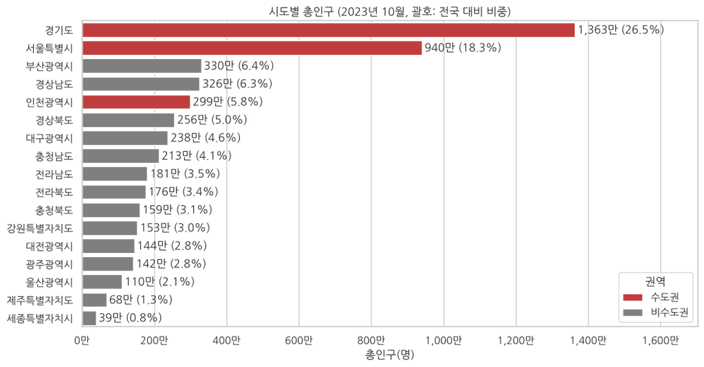

| 권역 | 총인구 | 인구비중(%) |
| --- | --- | --- |
| 비수도권 | 25335861 | 49.3 |
| 수도권 | 26018365 | 50.7 |

```python
sido['인구비중(%)'] = sido['총인구'] / sido['총인구'].sum() * 100
sido['권역'] = np.where(sido['시도'].isin(['서울특별시', '인천광역시', '경기도']), '수도권', '비수도권')
sido = sido.sort_values('총인구', ascending=False)

fig, ax = plt.subplots(figsize=(12, 6))
sns.barplot(data=sido, y='시도', x='총인구', hue='권역', dodge=False,
            palette={'수도권': 'tab:red', '비수도권': 'tab:gray'}, ax=ax)
ax.bar_label(ax.containers[0], labels=[f'{v/1e4:,.0f}만 ({p:.1f}%)' for v, p in
             zip(sido.loc[sido['권역'] == '수도권', '총인구'], sido.loc[sido['권역'] == '수도권', '인구비중(%)'])], padding=3)
ax.bar_label(ax.containers[1], labels=[f'{v/1e4:,.0f}만 ({p:.1f}%)' for v, p in
             zip(sido.loc[sido['권역'] == '비수도권', '총인구'], sido.loc[sido['권역'] == '비수도권', '인구비중(%)'])], padding=3)
ax.set_xlim(0, sido['총인구'].max() * 1.25)
ax.set_title('시도별 총인구 (2023년 10월, 괄호: 전국 대비 비중)')
ax.xaxis.set_major_formatter(lambda v, pos: f'{v/1e4:,.0f}만')
ax.set_xlabel('총인구(명)'); ax.set_ylabel('')
plt.show()

sido.groupby('권역')[['총인구', '인구비중(%)']].sum().round(1)
```

- 한줄 확인 : 경기도 **1,363만 명(26.5%)**, 서울 **940만 명(18.3%)** 이 1, 2위이고 가장 적은 곳은 세종(39만 명, 0.8%)
  - 수도권(서울·인천·경기)이 **50.7%(26,018,365명)** 로, 전체 인구의 절반 이상이 수도권에 산다.

```python
# 시도별 세대당 인구, 남여 비율 (값을 다시 계산해서 확인)
sido['남여비율_계산'] = (sido['남자'] / sido['여자']).round(2)
sido['세대당인구_계산'] = (sido['총인구'] / sido['세대수']).round(2)
sido_tbl = sido[['시도', '총인구', '세대수', '세대당인구', '세대당인구_계산', '남여비율', '남여비율_계산']]
print('파일의 값과 계산 값이 모두 같은가?',
      (sido_tbl['세대당인구'] == sido_tbl['세대당인구_계산']).all(),
      (sido_tbl['남여비율'] == sido_tbl['남여비율_계산']).all())
sido_tbl.sort_values('세대당인구')
```

```
파일의 값과 계산 값이 모두 같은가? True True
```

|  | 시도 | 총인구 | 세대수 | 세대당인구 | 세대당인구_계산 | 남여비율 | 남여비율_계산 |
| --- | --- | --- | --- | --- | --- | --- | --- |
| 2793 | 전라남도 | 1805823 | 911474 | 1.98 | 1.98 | 1.02 | 1.02 |
| 3140 | 경상북도 | 2558085 | 1282624 | 1.99 | 1.99 | 1.02 | 1.02 |
| 1915 | 강원특별자치도 | 1529500 | 760656 | 2.01 | 2.01 | 1.01 | 1.01 |
| 2531 | 전라북도 | 1757295 | 861451 | 2.04 | 2.04 | 0.99 | 0.99 |
| 2133 | 충청북도 | 1594211 | 779850 | 2.04 | 2.04 | 1.04 | 1.04 |
| 2303 | 충청남도 | 2128563 | 1033330 | 2.06 | 2.06 | 1.05 | 1.05 |
| 0 | 서울특별시 | 9400249 | 4472603 | 2.10 | 2.10 | 0.94 | 0.94 |
| 452 | 부산광역시 | 3298213 | 1564546 | 2.11 | 2.11 | 0.95 | 0.95 |
| 1112 | 대전광역시 | 1443965 | 680363 | 2.12 | 2.12 | 1.00 | 1.00 |
| 3500 | 경상남도 | 3255239 | 1524850 | 2.13 | 2.13 | 1.01 | 1.01 |
| 3837 | 제주특별자치도 | 676119 | 313291 | 2.16 | 2.16 | 1.00 | 1.00 |
| 674 | 대구광역시 | 2376978 | 1092922 | 2.17 | 2.17 | 0.97 | 0.97 |
| 1009 | 광주광역시 | 1421760 | 655675 | 2.17 | 2.17 | 0.98 | 0.98 |
| 836 | 인천광역시 | 2990276 | 1345719 | 2.22 | 2.22 | 1.00 | 1.00 |
| 1200 | 울산광역시 | 1104031 | 489851 | 2.25 | 2.25 | 1.06 | 1.06 |
| 1288 | 경기도 | 13627840 | 5971803 | 2.28 | 2.28 | 1.01 | 1.01 |
| 1262 | 세종특별자치시 | 386079 | 160556 | 2.40 | 2.40 | 0.99 | 0.99 |

- 한줄 확인 : 파일의 세대당 인구, 남여 비율은 직접 계산한 값과 모두 같다.
  - 세대당 인구가 가장 적은 곳은 **전라남도(1.98), 경상북도(1.99)**, 가장 많은 곳은 **세종(2.40), 경기도(2.28)**
  - 남여 비율은 **서울이 0.94로 가장 낮고**(여자가 더 많음), **울산이 1.06으로 가장 높다.**

#### 시도 → 시군구 인구 트리맵 (인터랙티브)

- 사각형의 크기 = 인구, 색 = 세대당 인구. 클릭하면 시도 안으로 들어가고, 가운데 위를 클릭하면 돌아온다.

```python
sgg['시군구'] = sgg['이름'].str.split().str[-1]
fig = px.treemap(sgg, path=[px.Constant('전국'), '시도', '시군구'], values='총인구',
                 color='세대당인구', color_continuous_scale='RdYlBu',
                 range_color=(1.6, 2.6), hover_data={'남여비율': True})
fig.update_traces(texttemplate='%{label}<br>%{value:,}명')
fig.update_layout(title='시도·시군구별 인구 (색: 세대당 인구)', height=650, margin=dict(t=50, l=10, r=10, b=10))
fig.show()
```

[interactive chart not shown]

- 한줄 확인 : 경기도(26.5%)와 서울(18.3%)이 전체 사각형의 약 45%를 차지한다. 색을 보면 **서울 관악구, 부산 중구** 같은 도심과 군 지역은 붉은색(세대당 인구가 적음), 신도시·택지지구가 많은 시는 파란색(많음) 쪽이다. (3·5장에서 숫자로 확인)

### 3. 시군구 순위 - 인구가 많은 / 적은 지역

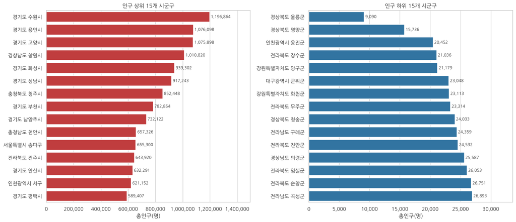

```python
sgg['순위'] = sgg['총인구'].rank(ascending=False).astype(int)
cols = ['순위', '이름', '총인구', '세대당인구', '남여비율']

top15 = sgg.nsmallest(15, '순위')[cols]
bottom15 = sgg.nlargest(15, '순위')[cols].sort_values('순위', ascending=False)

fig, axes = plt.subplots(1, 2, figsize=(16, 7))
for ax, data, title, color in [(axes[0], top15, '인구 상위 15개 시군구', 'tab:red'),
                               (axes[1], bottom15, '인구 하위 15개 시군구', 'tab:blue')]:
    sns.barplot(data=data, y='이름', x='총인구', color=color, ax=ax)
    ax.bar_label(ax.containers[0], labels=[f'{v:,}' for v in data['총인구']], padding=3, fontsize=9)
    ax.set_xlim(0, data['총인구'].max() * 1.25)
    ax.set_title(title); ax.set_ylabel(''); ax.set_xlabel('총인구(명)')
    ax.xaxis.set_major_formatter(lambda v, pos: f'{v:,.0f}')
plt.tight_layout()
plt.show()
```

```python
display(top15.head(5))
display(bottom15.head(5))
```

|  | 순위 | 이름 | 총인구 | 세대당인구 | 남여비율 |
| --- | --- | --- | --- | --- | --- |
| 1289 | 1 | 경기도 수원시 | 1196864 | 2.23 | 1.01 |
| 1685 | 2 | 경기도 용인시 | 1076098 | 2.47 | 0.98 |
| 1537 | 3 | 경기도 고양시 | 1075898 | 2.32 | 0.95 |
| 3501 | 4 | 경상남도 창원시 | 1010820 | 2.21 | 1.02 |
| 1794 | 5 | 경기도 화성시 | 939302 | 2.34 | 1.08 |

|  | 순위 | 이름 | 총인구 | 세대당인구 | 남여비율 |
| --- | --- | --- | --- | --- | --- |
| 3495 | 229 | 경상북도 울릉군 | 9090 | 1.63 | 1.25 |
| 3399 | 228 | 경상북도 영양군 | 15736 | 1.74 | 0.99 |
| 998 | 227 | 인천광역시 옹진군 | 20452 | 1.64 | 1.33 |
| 2731 | 226 | 전라북도 장수군 | 21036 | 1.82 | 1.01 |
| 2105 | 225 | 강원특별자치도 양구군 | 21179 | 2.00 | 1.10 |

- 한줄 확인 : 1위 **수원시(1,196,864명)**, 수원·용인·고양·창원 4곳이 인구 100만 명 이상. 상위 15곳 중 9곳이 경기도
  - 꼴찌 **울릉군(9,090명)** 은 수원시의 약 1/132. 하위 15곳은 모두 **군**이며 전라북도가 5곳(장수·무주·진안·임실·순창)

```python
# 시군구 인구 규모별 개수
bins = [0, 30_000, 100_000, 300_000, 500_000, 1_000_000, 2_000_000]
labels = ['3만 미만', '3~10만', '10~30만', '30~50만', '50~100만', '100만 이상']
sgg['규모'] = pd.cut(sgg['총인구'], bins=bins, labels=labels, right=False)

size_tbl = sgg.groupby('규모', observed=False).agg(시군구수=('이름', 'count'), 인구합계=('총인구', 'sum'))
size_tbl['인구비중(%)'] = (size_tbl['인구합계'] / size_tbl['인구합계'].sum() * 100).round(1)
size_tbl
```

| 규모 | 시군구수 | 인구합계 | 인구비중(%) |
| --- | --- | --- | --- |
| 3만 미만 | 20 | 476746 | 0.9 |
| 3~10만 | 73 | 4068074 | 7.9 |
| 10~30만 | 72 | 13827711 | 26.9 |
| 30~50만 | 43 | 17366435 | 33.8 |
| 50~100만 | 17 | 11255580 | 21.9 |
| 100만 이상 | 4 | 4359680 | 8.5 |

- 한줄 확인 : 인구 3만 미만 시군구가 **20곳**(인구 비중 0.9%), 10만 미만으로 넓히면 **93곳(229곳 중 41%)이 인구의 8.8%** 만 차지한다.
  - 인구 비중이 가장 큰 구간은 30~50만 명 시군구(43곳, 33.8%)

### 4. 성별 구조 - 성비가 높은 / 낮은 지역

- 남여 비율(성비) = 남자 ÷ 여자. 1보다 크면 남자가 더 많다.
- 이 파일에는 연령 정보가 없어 **성별 × 연령 피라미드는 만들 수 없지만**, 지역별 성비는 비교할 수 있다.

```python
total_m, total_f = sido['남자'].sum(), sido['여자'].sum()
print(f'전국 남자 {total_m:,}명 / 여자 {total_f:,}명 / 성비 {total_m/total_f:.3f}')

# 시군구 성비 계산 (파일의 소수 2자리 값 대신 직접 계산)
sgg['성비'] = sgg['남자'] / sgg['여자']
cols = ['이름', '총인구', '남자', '여자', '성비']
display(sgg.nlargest(7, '성비')[cols].round(3))
display(sgg.nsmallest(7, '성비')[cols].round(3))
```

```
전국 남자 25,582,773명 / 여자 25,771,453명 / 성비 0.993
```

|  | 이름 | 총인구 | 남자 | 여자 | 성비 |
| --- | --- | --- | --- | --- | --- |
| 998 | 인천광역시 옹진군 | 20452 | 11685 | 8767 | 1.333 |
| 3495 | 경상북도 울릉군 | 9090 | 5046 | 4044 | 1.248 |
| 2111 | 강원특별자치도 인제군 | 32003 | 17441 | 14562 | 1.198 |
| 3115 | 전라남도 신안군 | 38074 | 20502 | 17572 | 1.167 |
| 2099 | 강원특별자치도 화천군 | 23113 | 12405 | 10708 | 1.158 |
| 2429 | 충청남도 당진시 | 170097 | 90846 | 79251 | 1.146 |
| 2284 | 충청북도 음성군 | 91339 | 48521 | 42818 | 1.133 |

|  | 이름 | 총인구 | 남자 | 여자 | 성비 |
| --- | --- | --- | --- | --- | --- |
| 220 | 서울특별시 마포구 | 363953 | 170141 | 193812 | 0.878 |
| 644 | 부산광역시 수영구 | 174994 | 82136 | 92858 | 0.885 |
| 188 | 서울특별시 은평구 | 467124 | 221903 | 245221 | 0.905 |
| 205 | 서울특별시 서대문구 | 306927 | 145820 | 161107 | 0.905 |
| 3406 | 경상북도 영덕군 | 34154 | 16276 | 17878 | 0.910 |
| 362 | 서울특별시 서초구 | 407788 | 194384 | 213404 | 0.911 |
| 381 | 서울특별시 강남구 | 541565 | 258897 | 282668 | 0.916 |

- 한줄 확인 : 전국 성비는 **0.993**으로 여자가 188,680명 더 많다.
  - 남자가 많은 곳 : 인천 옹진군(1.333), 경북 울릉군(1.248), 강원 인제군(1.198), 전남 신안군(1.167), 강원 화천군(1.158) → **섬·접경 지역**, 충남 당진시(1.146)·충북 음성군(1.133) → **산업단지 지역**
  - 여자가 많은 곳 : 서울 마포구(0.878), 부산 수영구(0.885), 서울 은평구·서대문구(0.905) 등 **대도시의 구**가 대부분 (경북 영덕군 0.910만 예외)

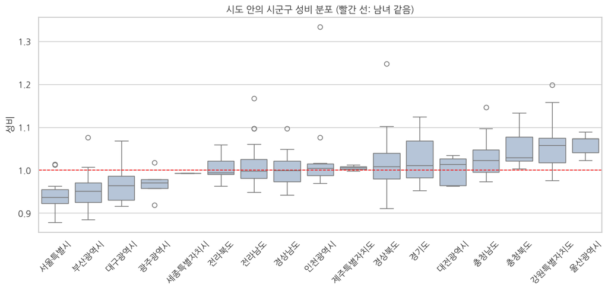

| 시도 | 서울특별시 | 부산광역시 | 대구광역시 | 광주광역시 | 세종특별자치시 | 전라북도 | 전라남도 | 경상남도 | 인천광역시 | 제주특별자치도 | 경상북도 | 경기도 | 대전광역시 | 충청남도 | 충청북도 | 강원특별자치도 | 울산광역시 |
| --- | --- | --- | --- | --- | --- | --- | --- | --- | --- | --- | --- | --- | --- | --- | --- | --- | --- |
| 성비 중앙값 | 0.937 | 0.951 | 0.964 | 0.97 | 0.992 | 0.994 | 0.999 | 1.0 | 1.005 | 1.005 | 1.009 | 1.011 | 1.014 | 1.023 | 1.029 | 1.057 | 1.074 |

```python
fig, ax = plt.subplots(figsize=(13, 5))
order = sgg.groupby('시도')['성비'].median().sort_values().index
sns.boxplot(data=sgg, x='시도', y='성비', order=order, color='lightsteelblue', ax=ax)
ax.axhline(1, color='red', ls='--', lw=1)
ax.set_title('시도 안의 시군구 성비 분포 (빨간 선: 남녀 같음)')
ax.set_xlabel(''); ax.tick_params(axis='x', rotation=45)
plt.show()

# 시도별 시군구 성비 중앙값
sgg.groupby('시도')['성비'].median().sort_values().round(3).to_frame('성비 중앙값').T
```

- 한줄 확인 : 서울은 시군구 성비 중앙값이 **0.937로 가장 낮고**, 25개 구 중 2곳(금천구·관악구, 약 1.01)을 빼면 모두 1보다 낮다.
  - **울산(1.074), 강원(1.057), 충북(1.029)** 은 중앙값이 1보다 높다. 대도시(서울·부산·대구·광주)는 여초, 산업도시·도 지역은 남초 경향

### 5. 세대 구조 - 세대당 인구가 적은 / 많은 지역

- 세대당 인구가 적다 = **1인 세대(혼자 사는 세대)가 많다**는 신호. 대학가·원룸촌, 고령층이 많은 농어촌에서 낮게 나타나는 경향이 있다.
- 세대당 인구가 많다 = 자녀가 있는 가족 세대가 많은 **신도시·택지지구** 경향

```python
cols = ['이름', '총인구', '세대수', '세대당인구']
print('[세대당 인구가 적은 시군구]')
display(sgg.nsmallest(8, '세대당인구')[cols])
print('[세대당 인구가 많은 시군구]')
display(sgg.nlargest(8, '세대당인구')[cols])
print('전국 세대당 인구:', round(sido['총인구'].sum() / sido['세대수'].sum(), 2))
```

```
[세대당 인구가 적은 시군구]
```

|  | 이름 | 총인구 | 세대수 | 세대당인구 |
| --- | --- | --- | --- | --- |
| 453 | 부산광역시 중구 | 38831 | 23798 | 1.63 |
| 3495 | 경상북도 울릉군 | 9090 | 5591 | 1.63 |
| 998 | 인천광역시 옹진군 | 20452 | 12471 | 1.64 |
| 827 | 대구광역시 군위군 | 23048 | 13626 | 1.69 |
| 3055 | 전라남도 함평군 | 30604 | 18056 | 1.69 |
| 340 | 서울특별시 관악구 | 483959 | 285450 | 1.70 |
| 3371 | 경상북도 의성군 | 50165 | 29461 | 1.70 |
| 2963 | 전라남도 보성군 | 37785 | 22040 | 1.71 |

```
[세대당 인구가 많은 시군구]
```

|  | 이름 | 총인구 | 세대수 | 세대당인구 |
| --- | --- | --- | --- | --- |
| 1585 | 경기도 과천시 | 81143 | 29404 | 2.76 |
| 1240 | 울산광역시 북구 | 216567 | 87665 | 2.47 |
| 1663 | 경기도 의왕시 | 158242 | 64086 | 2.47 |
| 1685 | 경기도 용인시 | 1076098 | 435212 | 2.47 |
| 885 | 인천광역시 연수구 | 390896 | 159414 | 2.45 |
| 1452 | 경기도 광명시 | 280270 | 115080 | 2.44 |
| 237 | 서울특별시 양천구 | 437199 | 181038 | 2.41 |
| 1602 | 경기도 남양주시 | 732122 | 304119 | 2.41 |

```
전국 세대당 인구: 2.15
```

- 한줄 확인 : 전국 세대당 인구는 **2.15명**
  - 가장 적은 곳 : 부산 중구·경북 울릉군(1.63), 인천 옹진군(1.64), 대구 군위군·전남 함평군(1.69) 등 **원도심과 농어촌 군**. 서울 **관악구(1.70)** 는 인구 48만의 대도시 구인데도 8위 안에 든다(청년 1인 세대가 많은 지역).
  - 가장 많은 곳 : **경기 과천시(2.76)**, 울산 북구·경기 의왕시·용인시(2.47), 인천 연수구(2.45) → 신도시·택지지구 중심

#### 인구 규모 vs 세대당 인구 (인터랙티브)

- 점 하나가 시군구. 마우스를 올리면 지역 이름과 값이 보인다. x축은 로그 눈금.

```python
sgg['권역'] = np.where(sgg['시도'].isin(['서울특별시', '인천광역시', '경기도']), '수도권', '비수도권')
fig = px.scatter(sgg, x='총인구', y='세대당인구', color='권역', size='세대수', size_max=30,
                 hover_name='이름', hover_data={'총인구': ':,', '세대수': ':,', '성비': ':.3f', '권역': False},
                 log_x=True, color_discrete_map={'수도권': 'crimson', '비수도권': 'gray'})
fig.update_layout(title='시군구 인구 규모 vs 세대당 인구 (점 크기: 세대수)', height=550)
fig.show()

print('인구(로그)와 세대당 인구의 상관계수:', round(np.log10(sgg['총인구']).corr(sgg['세대당인구']), 3))
print(sgg.groupby('권역')['세대당인구'].median().round(2).to_string())
```

[interactive chart not shown]

```
인구(로그)와 세대당 인구의 상관계수: 0.779
권역
비수도권    1.95
수도권     2.19
```

- 한줄 확인 : 인구(로그)와 세대당 인구의 상관계수가 **0.779**로, **인구가 많은 시군구일수록 세대당 인구가 많다.** 인구가 적은 군 지역은 1~2인 세대 비율이 높다는 뜻으로 볼 수 있다.
  - 세대당 인구 중앙값 : 수도권 **2.19** vs 비수도권 **1.95**
  - 관악구처럼 인구가 많은데 세대당 인구가 낮은 점은 예외적인 지역이다. (마우스로 확인)

### 6. 읍면동 단위 - 인구는 얼마나 몰려 있을까?

- 읍면동은 3,500개가 넘으므로, **인구가 많은 읍면동부터 쌓아 올렸을 때** 전체 인구의 몇 %가 되는지(누적 비중)로 집중도를 본다.

```python
dong_pop = dong.loc[dong['총인구'] > 0, ['이름', '총인구', '세대당인구', '남여비율']].copy()
print('인구가 있는 읍면동 수:', len(dong_pop))
print(dong_pop['총인구'].describe().round(0).to_string())

display(dong_pop.nlargest(5, '총인구'))
display(dong_pop.nsmallest(5, '총인구'))
```

```
인구가 있는 읍면동 수: 3585
count      3585.0
mean      14325.0
std       13660.0
min          52.0
25%        3281.0
50%       10404.0
75%       21284.0
max      128112.0
```

|  | 이름 | 총인구 | 세대당인구 | 남여비율 |
| --- | --- | --- | --- | --- |
| 1445 | 경기도 부천시 신중동 | 128112 | 2.31 | 0.93 |
| 3688 | 경상남도 양산시 물금읍 | 119778 | 2.44 | 0.98 |
| 1618 | 경기도 남양주시 다산1동 | 101341 | 2.54 | 0.96 |
| 1449 | 경기도 부천시 범안동 | 100086 | 2.49 | 0.96 |
| 1604 | 경기도 남양주시 진접읍 | 96154 | 2.42 | 1.01 |

|  | 이름 | 총인구 | 세대당인구 | 남여비율 |
| --- | --- | --- | --- | --- |
| 450 | 서울특별시 강동구 둔촌제1동 | 52 | 1.58 | 1.26 |
| 1453 | 경기도 광명시 광명1동 | 55 | 1.12 | 0.96 |
| 2094 | 강원특별자치도 철원군 근북면 | 100 | 1.67 | 0.89 |
| 1893 | 경기도 연천군 중면 | 165 | 1.74 | 1.39 |
| 2948 | 전라남도 고흥군 도양읍시산출장소 | 194 | 1.46 | 0.98 |

- 한줄 확인 : 인구가 있는 읍면동 3,585개, 중앙값 **10,404명**, 평균 14,325명 (평균 > 중앙값 → 큰 동이 평균을 끌어올림)
  - 가장 큰 곳은 경기 부천시 신중동(128,112명), 양산시 물금읍(119,778명) 등 신도시 지역
  - 가장 작은 곳은 서울 강동구 둔촌제1동(52명), 경기 광명시 광명1동(55명)으로, 대도시 안에서도 재건축·재개발로 주민이 빠져나간 곳으로 보인다.

```
인구 상위 10% 읍면동이 전체 인구의 30.6%
인구 상위 20% 읍면동이 전체 인구의 50.0%
인구 상위 50% 읍면동이 전체 인구의 85.5%
```

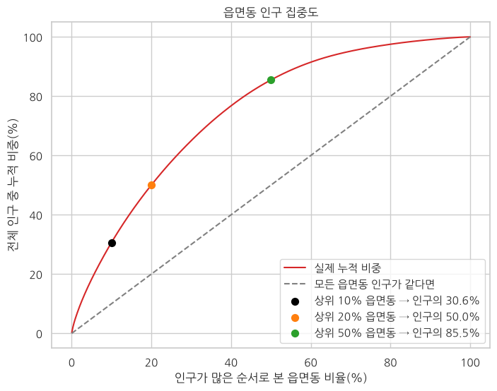

```python
share = dong_pop['총인구'].sort_values(ascending=False).cumsum() / dong_pop['총인구'].sum() * 100
x = np.arange(1, len(share) + 1) / len(share) * 100

fig, ax = plt.subplots(figsize=(8, 6))
ax.plot(x, share.values, color='tab:red', label='실제 누적 비중')
ax.plot([0, 100], [0, 100], ls='--', color='gray', label='모든 읍면동 인구가 같다면')
for p, c in zip([10, 20, 50], ['black', 'tab:orange', 'tab:green']):
    v = share.iloc[int(len(share) * p / 100) - 1]
    ax.scatter(p, v, color=c, s=50, zorder=3, label=f'상위 {p}% 읍면동 → 인구의 {v:.1f}%')
    print(f'인구 상위 {p}% 읍면동이 전체 인구의 {v:.1f}%')
ax.set_xlabel('인구가 많은 순서로 본 읍면동 비율(%)')
ax.set_ylabel('전체 인구 중 누적 비중(%)')
ax.set_title('읍면동 인구 집중도')
ax.legend(loc='lower right')
plt.show()
```

- 한줄 확인 : 인구 상위 **10%** 읍면동에 전체 인구의 **30.6%**, 상위 **20%** 에 **50.0%**, 상위 **50%** 에 **85.5%** 가 산다.
  - 읍면동 5곳 중 1곳에 인구의 절반이 모여 있다.

```python
# 기본 분석에서 본 구로구를 전국과 비교해 보기
guro = dong[dong['이름'].str.startswith('서울특별시 구로구')]
print('구로구 동 수:', len(guro), '/ 동 평균 인구:', f"{guro['총인구'].mean():,.0f}",
      '/ 전국 읍면동 중앙값:', f"{dong_pop['총인구'].median():,.0f}")
print('구로구 순위(시군구 중):', sgg.loc[sgg['이름'] == '서울특별시 구로구', '순위'].iloc[0], '/', len(sgg))
guro[['이름', '총인구', '세대당인구', '남여비율']].sort_values('남여비율', ascending=False).head(4)
```

```
구로구 동 수: 16 / 동 평균 인구: 24,591 / 전국 읍면동 중앙값: 10,404
```

```
구로구 순위(시군구 중): 43 / 229
```

|  | 이름 | 총인구 | 세대당인구 | 남여비율 |
| --- | --- | --- | --- | --- |
| 284 | 서울특별시 구로구 가리봉동 | 8782 | 1.45 | 1.21 |
| 281 | 서울특별시 구로구 구로제3동 | 23326 | 1.71 | 1.08 |
| 280 | 서울특별시 구로구 구로제2동 | 22536 | 1.85 | 1.01 |
| 285 | 서울특별시 구로구 고척제1동 | 26325 | 2.28 | 0.99 |

- 한줄 확인 : 기본 분석의 구로구는 16개 동, 동 평균 인구 **24,591명**으로 전국 읍면동 중앙값(10,404명)의 약 2.4배이며, 시군구 인구 순위는 229곳 중 **43위**
  - 가리봉동은 성비 **1.21**, 세대당 인구 **1.45**로 구로구 안에서 남자와 1인 세대가 특히 많은 동이다.

### 7. 정리

| 질문 | 기본 분석 | 추가 분석 결과 |
| --- | --- | --- |
| 데이터 구조는? | 3,883행 × 7열, 쉼표 때문에 문자형 | 시도 17 / 시군구 229(인구 0인 출장소 13곳 제외) / 일반구 32 / 읍면동 3,592가 섞여 있음 → 코드로 나누면 세 단계 합계가 모두 **51,354,226명**으로 일치 |
| 인구는 어디에 몰려 있을까? | 구로구 동별 남자 인구만 확인 | 수도권 **50.7%**, 경기도 26.5% + 서울 18.3%. 읍면동 상위 20%에 인구의 **50.0%** |
| 인구가 많은 / 적은 시군구는? | - | 1위 수원시 1,196,864명 (100만 이상 4곳), 꼴찌 울릉군 9,090명. 인구 10만 미만 93곳이 인구의 8.8% |
| 남녀 구성은 지역마다 다를까? | - | 전국 성비 0.993. 남초 : 옹진군 1.333 등 섬·접경·산업단지, 여초 : 마포구 0.878 등 대도시 구. 서울 시군구 성비 중앙값 0.937로 최저 |
| 혼자 사는 세대가 많은 곳은? | - | 전국 세대당 2.15명. 부산 중구·울릉군 1.63 최저, 과천시 2.76 최고. 인구가 많을수록 세대당 인구가 많음(r = 0.779) |
| 고령화 비율, 인구 피라미드는? | - | **이 파일에는 연령 정보가 없어 분석할 수 없음** → 연령별 인구현황 데이터 필요 |

#### 배운 점

- 공공 데이터는 먼저 **인코딩(cp949)과 숫자 형식(쉼표)** 을 확인하고, `thousands=','`로 바로 숫자로 읽을 수 있다.
- 행정구역처럼 **여러 단계가 한 컬럼에 섞인 데이터**는 코드로 단계를 나누고, **합계가 맞는지 검증**한 뒤 분석해야 한다.
- 같은 "인구"라도 세대당 인구, 성비 같은 **비율 지표**를 함께 보면 지역의 성격(대학가, 신도시, 산업도시)이 드러난다.

#### 다음에 해 볼 분석

- 행정안전부 주민등록 인구통계에서 **연령별 인구현황**(5세 또는 10세 단위, 남/여 구분)을 내려받아
  - 시군구별 **고령화 비율(65세 이상 비율)** 과 순위, 초고령사회(20% 이상) 지역 수
  - 전국 / 특정 지역의 **인구 피라미드**
- 여러 달의 데이터를 모아 **인구 증감**이 큰 지역 찾기
- 행정구역 경계(GeoJSON)와 코드를 연결해 **지도 시각화**(folium choropleth)